# 22100 - R for Bio Data Science

## Neoepitopes arise from somatic mutations in the tumor…

…they are not expressed in normal cells and are optimal targets for immunetherapy approaches

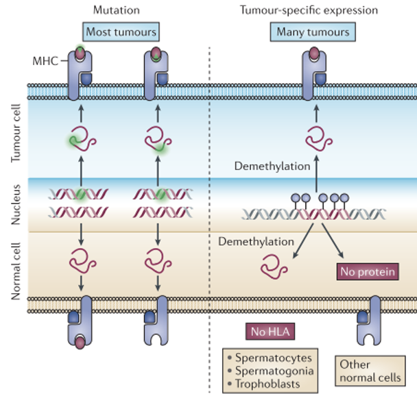

## Objectives - Elucidation of detected neoepitope characteristics

- Merging Mupexi file with Barracoda file

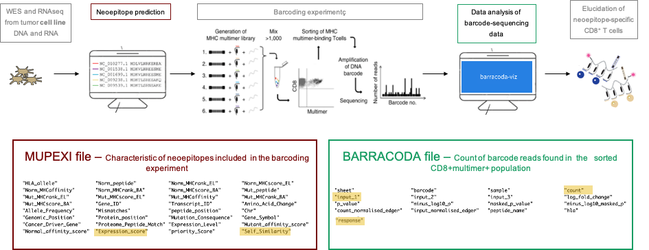

## Method

- Data generation from mouse tumor models
- Two cell lines (CT26 colon carcinoma and 4T1 breast cancer)
- Two organs (spleen and tumors)
- With and without checkpoint inhibitor treatment
- Structure in two columns.
- Roadmap of data analysis in the code

## Results

## 1) Response filtering

- Response selection criteria: logfold change > 2 and p-value < 0.01

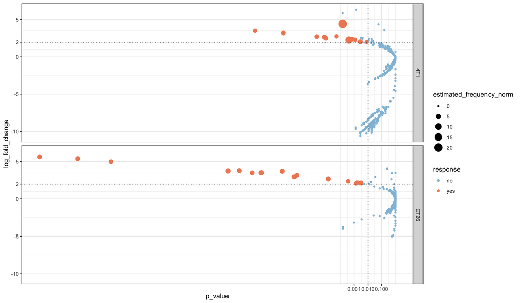

## Barracoda selection

- I dont know how to remove thw white space to make the plot bigger
- lof fold change of barcode reads across cell lines and treatments

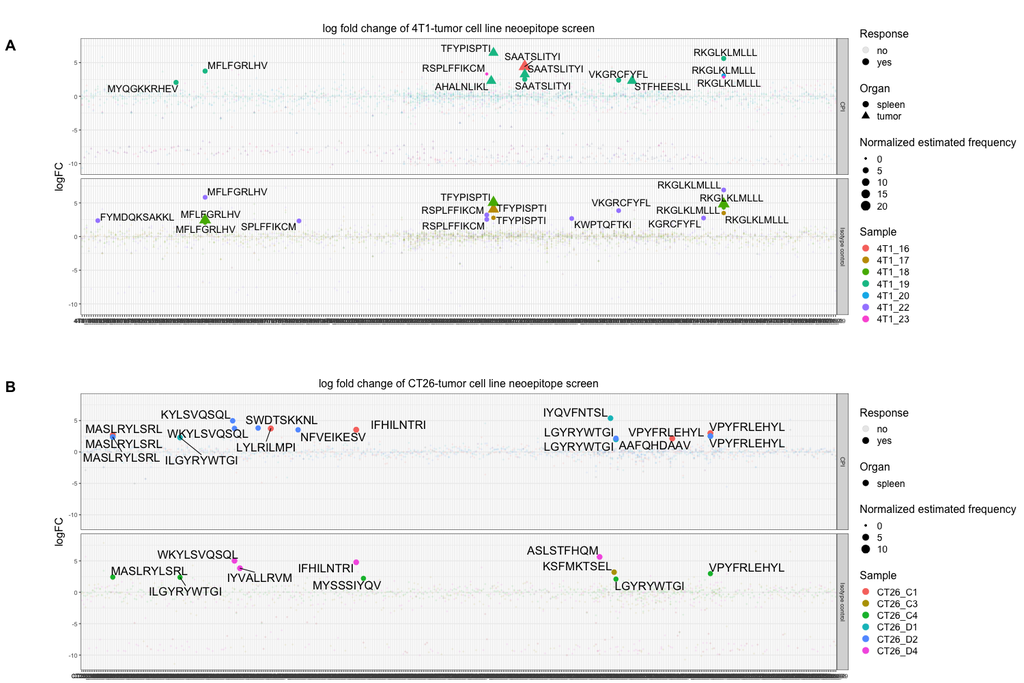

## Expression level and rank score

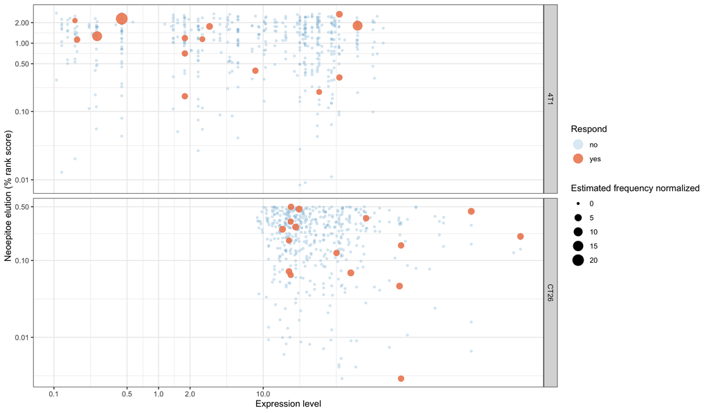

## Mutation consequence

- Can mutation type be used to find immunugenic neoepitopes?

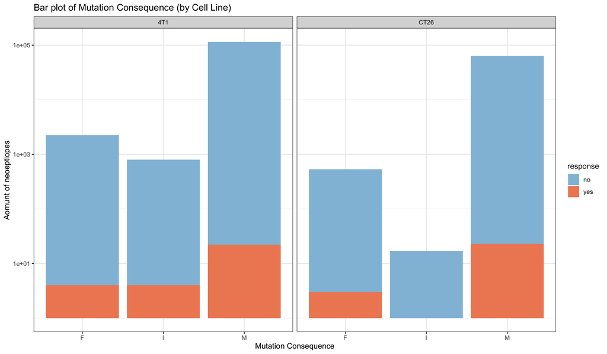

## Elution, binding affinity rank scores and self-similarity

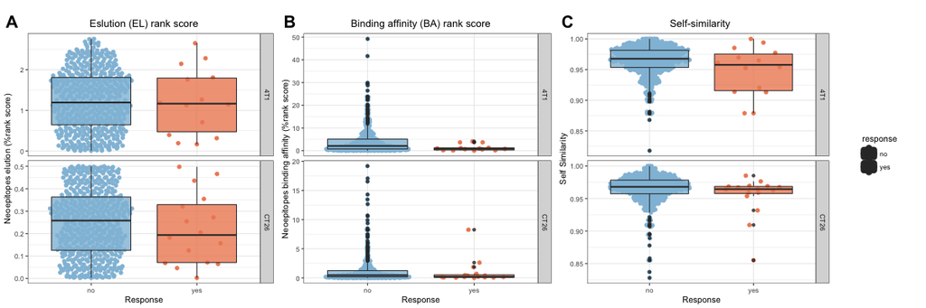

## Improved binding affinity

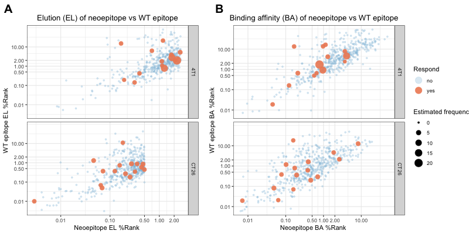

## Mutation position

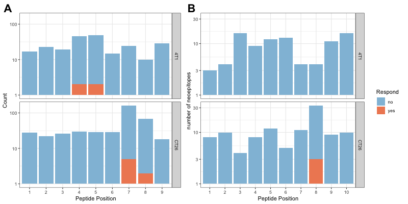

## GGseq logo

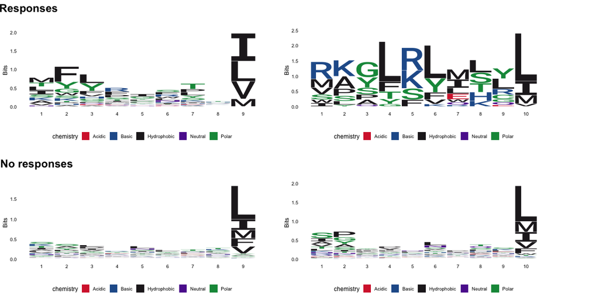

## Modelling

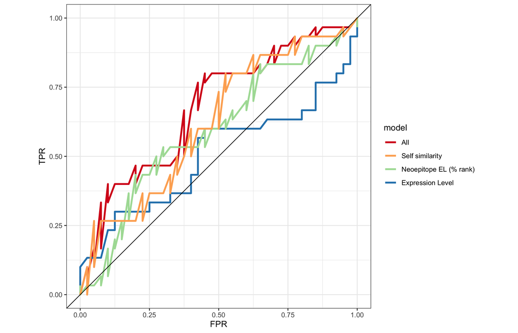

## Discussion

- Data set is to small to see a clear pattern in immnunugenic and non-immunugenic neoepitopes

Further work:

- Try out with more data, when more peptides are screened
- Is the results the same for human data
- Make packages for human data

## R package and shiny app

We have developed barcc package, which includes a shiny app for rapid visualization of the data.